```python
# Initialize Otter
import otter
grader = otter.Notebook("hw6.ipynb")
```

# Homework 6: Exploring Uber and Lyft Prices in Boston

Name: Dylan Alfonso

Student ID: 498203

Collaborators:

## Instructions

This homework is an *open-ended midterm project* for our class.

We will be using the techniques and approaches introduced in the first half of the semester:

- **[M0] Python for DS**
- **[M1] The DS and ML Workflows**
- **[M2] Exploratory Data Analsyis**
- [M3] Linear Regression (if applicable - depends on problem/dataset)
- [M4] Linear Classification (if applicable - depends on problem/dataset)
- [M5] Sentiment Analysis (if applicable - depends on problem/dataset)
- **[M6]** Learning Principles and **Ethical Thinking for DS**

The main focus of this project is on the first three modules [M0]-[M2], as well as the ethical consderations for DS from [M6]. In particular, it will be helpful to review **Lab 2 & hw2 (Analyzing the MoMA Data)** first. Most of the things you will do in this midterm project are explained in `Lab2` and `hw2`. Then, review the other labs and hws to recap the general workflow of our DS approaches to the various problems we have worked on so far. This will help you to be prepared for all the steps in this project, so that you do not miss anything.

In gernal, you should feel free to import any package that we have previously used in class. Ensure that all plots have the necessary components that a plot should have (e.g. axes labels, a title, a legend). However, **do not install and use other packages from what we have set up in our cse217a conda environment!**

Additionally, note that this assignment is more like a project than a typical homework and it will have a slightly different structure than the hws in the past. One of the reasons why Jupyter Notebooks are so popular in the field is because you can really treat them like notebooks to explain your findings as you discover them. In this assignment, we provide some **Problem** stubs following the EDA/DS workflow and you will need to fill in the analysis and structure as you go.

Furthermore, in addition to recording your collaborators on this homework, please also remember to cite/indicate all external sources used when finishing this assignment. This includes peers, TAs, and links to online sources.

Frequently **save** your notebook!

### Collaborators and Sources

Furthermore, in addition to recording your **collaborators** on this homework, please also remember to **cite/indicate all external sources** used when finishing this assignment.

> This includes peers, TAs, and links to online sources.

Note that these citations will not free you from your obligation to submit your *own* code and write-ups, however, they will be taken into account during the grading and regrading process.

```python
# collaborators and sources:
# Albert Einstein and Marie Curie
# https://developers.google.com/edu/python/strings
# https://stackoverflow.com/questions/54733465/pandas-how-to-extract-hhmm-from-datetime-column-in-python
# https://note.nkmk.me/en/python-pandas-multiple-conditions/
# your code here
answer = 'my answer'
```

### Submission instructions

- Submit this Python notebook, including your answers in the code cells as homework submission.
- **Feel free to add as many cells as you need to** — just make sure you don't change what we gave you.
- **Does it spark joy?** Note that you will be partially graded on the presentation (*cleanliness, clarity, comments*) of your notebook so make sure you [Marie Kondo](https://lifehacker.com/marie-kondo-is-not-a-verb-1833373654) your notebook before submitting it.

## 1. Introduction

For our midterm project this semester, we'll take a look at data for numerous Lyft and Uber rides in Boston and their prices (https://www.kaggle.com/brllrb/uber-and-lyft-dataset-boston-ma). Our goal will be to use this dataset to gain some insight about characteristics of rides and *perhaps* find some patterns in this data.

In general, we will be following the EDA process:

1. Get the data and gain **basic understanding**
2. **Wrangle** the data
3. **Profile** the data
4. Develop questions to investigate (form a **hypotheses**)
5. Use the data to **investigate** hypothesis
6. **Summarize** results and answer questions
7. **Critically review** our workflow and discuss ethical concerns

## 2. Getting Familiar with the Data

In this section, we will get a feel for our data and tidy it up so that we can analyize it later. Download the data from the source/link given above and be sure to save the data in a folder called `data` under the `utility` directory. Your final path should look like `utility/data/rideshare_kaggle.csv` -- if it doesn't **we will not be able to properly grade your assignment!**

### Problem 1

Let's take a look at the file in `utility/data` and think about what we can and will need to do with it.

**Write-up!** Describe the data, answering questions including, but not limited to, these: Where does the data come from? How was it obtained? How many examples and features does the dataset have? What kinds of features are in the dataset? What values can these features take?

> **Hint**: Consider the steps of EDA; what would you like to know about this dataset.

**Answer here:** (feel free to make multiple cells!)

The dataset is a sample dataset for Uber & Lyft price pings in Boston. It appears as though this data comes from uber and lyft, but I'm not sure how the author of the dataset obtained it. There are 693,071 unique examples and 57 features. The amount of examples is an indicator of how many rides we are analyzing. The features include such as timestamp(float), hour(int), day(int), month(int),datetime(String), timezone(String) etc... These represent different features of the ride.

### Problem 2

Let's do some data wrangling.

**Write up!** Considering your description of the dataset from Problem 1, how should we clean this data?

**Do this!** In the cells below, **explain** and perform the steps that you need to prepare this data for further analysis. Make sure that your implementations and write-ups (for processing and analysis) are presented well and effectively describe your workflow. You may add comments or markdown cells for your documentation as you see fit!

*Grading Note: Your work will be graded for *readability*, *style*, and *cleanlines*. So, carefully document your code and use descriptive/intuitive variable names. For write-ups use consice and clear language like in a written project report.*

> **Hint**: You can use our previous labs as examples of how you might do this. Also, you might want to come back to this step later on, since you might encounter problems with the data once you actually analyze it. Remember, you may add as many cells (for code and text) as you need below. Here — we gave you one for free!

In this cell we imported panda and read in the data. I would print it out but it's a waste of space :)

```python
import pandas as pd
data = pd.read_csv("./utility/data/rideshare_kaggle.csv")
```

We like the idea of timestamp, but it appears to still be a String, let's convert that to datetime to make it more useful.

```python
data['datetime'] = pd.to_datetime(data['datetime'])
```

```python
data = data.dropna()
```

### Problem 3

**Do this!** Now that we cleaned up our data, we are ready to look into it. In this problem, we want to profile our data and explore its variables.

> **Hint**: Note that the way some data is stored does not necesarily mean that each column should correspond to a seperate variable. Feel free to define your own variables based on the input data. Looking at the dataset documentation might be helpful to figure out meaningful representations. Also note that there are no right or wrong representations here (since it is your job to find something interesting in the data, it is also up to you to choose the data/variable representations). Again, you might want to iterate over this step again later after doing some more exploration.

> **Hint**: Recall from Lab 2, this step usually involves computing summary statistics and basic plots *where applicable*. Try plotting some of the data (with appropriate plots; remember the lecture content - some plots introduced in there ( we did not yet use in the lab or hw) could be useful). Then, highlight a few of the more interesting ones and discuss why you thought they were interesting — for both our sakes, **please only include the most interesting ones** in your actual submission!! Again note that there are no right or wrong features to choose here (since it is your job to find something interesting in the data, it is also up to you to choose the data/variables to include). Just be sure to make a selection. You will not receive any credit by simply plotting everything!

*Grading Note*: Your work will be graded for *creativity* and *aesthetics*. Be creative in the plots you use and select visulatizations and colors that make for a plesant and intuitive viewing expereince. The goal of a good visualization is that the viewer will quickly understand your figures.*

Once again, we have provided a *free* cell for you to use; make as many as you need. Use text/markdown cells to describe what you are doing and what your findings are.

Let's section up our data to look at more important things. For example, here is our numeric data.

```python
# this one is also free!
numeric = data.describe().transpose()
numeric
```

|  | count | mean | std | min | 25% | 50% | 75% | max |
| --- | --- | --- | --- | --- | --- | --- | --- | --- |
| timestamp | 637976.0 | 1.544046e+09 | 689202.790112 | 1.543204e+09 | 1.543444e+09 | 1.543737e+09 | 1.544828e+09 | 1.545161e+09 |
| hour | 637976.0 | 1.161853e+01 | 6.948776 | 0.000000e+00 | 6.000000e+00 | 1.200000e+01 | 1.800000e+01 | 2.300000e+01 |
| day | 637976.0 | 1.779767e+01 | 9.982083 | 1.000000e+00 | 1.300000e+01 | 1.700000e+01 | 2.800000e+01 | 3.000000e+01 |
| month | 637976.0 | 1.158655e+01 | 0.492452 | 1.100000e+01 | 1.100000e+01 | 1.200000e+01 | 1.200000e+01 | 1.200000e+01 |
| price | 637976.0 | 1.654513e+01 | 9.324359 | 2.500000e+00 | 9.000000e+00 | 1.350000e+01 | 2.250000e+01 | 9.750000e+01 |
| distance | 637976.0 | 2.189261e+00 | 1.135413 | 2.000000e-02 | 1.270000e+00 | 2.160000e+00 | 2.930000e+00 | 7.860000e+00 |
| surge_multiplier | 637976.0 | 1.015068e+00 | 0.095422 | 1.000000e+00 | 1.000000e+00 | 1.000000e+00 | 1.000000e+00 | 3.000000e+00 |
| latitude | 637976.0 | 4.233816e+01 | 0.047856 | 4.221480e+01 | 4.235030e+01 | 4.235190e+01 | 4.236470e+01 | 4.236610e+01 |
| longitude | 637976.0 | -7.106614e+01 | 0.020303 | -7.110540e+01 | -7.108100e+01 | -7.106310e+01 | -7.105420e+01 | -7.103300e+01 |
| temperature | 637976.0 | 3.958241e+01 | 6.725500 | 1.891000e+01 | 3.645000e+01 | 4.049000e+01 | 4.358000e+01 | 5.722000e+01 |
| apparentTemperature | 637976.0 | 3.587844e+01 | 7.917260 | 1.213000e+01 | 3.191000e+01 | 3.590000e+01 | 4.001000e+01 | 5.722000e+01 |
| precipIntensity | 637976.0 | 8.909317e-03 | 0.026880 | 0.000000e+00 | 0.000000e+00 | 0.000000e+00 | 0.000000e+00 | 1.447000e-01 |
| precipProbability | 637976.0 | 1.459412e-01 | 0.328776 | 0.000000e+00 | 0.000000e+00 | 0.000000e+00 | 0.000000e+00 | 1.000000e+00 |
| humidity | 637976.0 | 7.410557e-01 | 0.138575 | 3.800000e-01 | 6.400000e-01 | 7.100000e-01 | 8.800000e-01 | 9.600000e-01 |
| windSpeed | 637976.0 | 6.186795e+00 | 3.147856 | 4.500000e-01 | 3.410000e+00 | 5.910000e+00 | 8.410000e+00 | 1.500000e+01 |
| windGust | 637976.0 | 8.470616e+00 | 5.288683 | 8.000000e-01 | 4.060000e+00 | 7.550000e+00 | 1.174000e+01 | 2.725000e+01 |
| windGustTime | 637976.0 | 1.544049e+09 | 692850.701695 | 1.543151e+09 | 1.543432e+09 | 1.543756e+09 | 1.544846e+09 | 1.545127e+09 |
| visibility | 637976.0 | 8.469180e+00 | 2.601828 | 7.170000e-01 | 8.432000e+00 | 9.880000e+00 | 9.996000e+00 | 1.000000e+01 |
| temperatureHigh | 637976.0 | 4.503959e+01 | 5.996033 | 3.268000e+01 | 4.257000e+01 | 4.466000e+01 | 4.691000e+01 | 5.787000e+01 |
| temperatureHighTime | 637976.0 | 1.544050e+09 | 693821.060871 | 1.543154e+09 | 1.543439e+09 | 1.543788e+09 | 1.544814e+09 | 1.545160e+09 |
| temperatureLow | 637976.0 | 3.414893e+01 | 6.381731 | 1.785000e+01 | 3.017000e+01 | 3.418000e+01 | 3.873000e+01 | 4.660000e+01 |
| temperatureLowTime | 637976.0 | 1.544102e+09 | 692313.312579 | 1.543234e+09 | 1.543489e+09 | 1.543817e+09 | 1.544836e+09 | 1.545221e+09 |
| apparentTemperatureHigh | 637976.0 | 4.161251e+01 | 7.665189 | 2.262000e+01 | 3.657000e+01 | 4.095000e+01 | 4.412000e+01 | 5.720000e+01 |
| apparentTemperatureHighTime | 637976.0 | 1.544050e+09 | 694198.042258 | 1.543187e+09 | 1.543439e+09 | 1.543788e+09 | 1.544818e+09 | 1.545160e+09 |
| apparentTemperatureLow | 637976.0 | 3.013797e+01 | 8.056278 | 1.181000e+01 | 2.770000e+01 | 3.003000e+01 | 3.532000e+01 | 4.725000e+01 |
| apparentTemperatureLowTime | 637976.0 | 1.544099e+09 | 692757.969879 | 1.543234e+09 | 1.543478e+09 | 1.543817e+09 | 1.544836e+09 | 1.545199e+09 |
| dewPoint | 637976.0 | 3.165228e+01 | 9.141390 | 4.390000e+00 | 2.749000e+01 | 3.069000e+01 | 3.812000e+01 | 5.067000e+01 |
| pressure | 637976.0 | 1.010093e+03 | 13.475580 | 9.880900e+02 | 9.998200e+02 | 1.009250e+03 | 1.021860e+03 | 1.035550e+03 |
| windBearing | 637976.0 | 2.201127e+02 | 99.087172 | 2.000000e+00 | 1.240000e+02 | 2.580000e+02 | 3.030000e+02 | 3.560000e+02 |
| cloudCover | 637976.0 | 6.862907e-01 | 0.358599 | 0.000000e+00 | 3.700000e-01 | 8.200000e-01 | 1.000000e+00 | 1.000000e+00 |
| uvIndex | 637976.0 | 2.490313e-01 | 0.474306 | 0.000000e+00 | 0.000000e+00 | 0.000000e+00 | 0.000000e+00 | 2.000000e+00 |
| visibility.1 | 637976.0 | 8.469180e+00 | 2.601828 | 7.170000e-01 | 8.432000e+00 | 9.880000e+00 | 9.996000e+00 | 1.000000e+01 |
| ozone | 637976.0 | 3.135156e+02 | 27.951377 | 2.694000e+02 | 2.909000e+02 | 3.074000e+02 | 3.318000e+02 | 3.789000e+02 |
| sunriseTime | 637976.0 | 1.544027e+09 | 691163.407229 | 1.543147e+09 | 1.543406e+09 | 1.543752e+09 | 1.544789e+09 | 1.545135e+09 |
| sunsetTime | 637976.0 | 1.544060e+09 | 690687.509513 | 1.543181e+09 | 1.543440e+09 | 1.543785e+09 | 1.544822e+09 | 1.545168e+09 |
| moonPhase | 637976.0 | 5.790764e-01 | 0.244674 | 9.000000e-02 | 3.000000e-01 | 6.800000e-01 | 7.900000e-01 | 9.300000e-01 |
| precipIntensityMax | 637976.0 | 3.736905e-02 | 0.055216 | 0.000000e+00 | 0.000000e+00 | 4.000000e-04 | 9.160000e-02 | 1.459000e-01 |
| uvIndexTime | 637976.0 | 1.544044e+09 | 691226.766445 | 1.543162e+09 | 1.543421e+09 | 1.543770e+09 | 1.544807e+09 | 1.545152e+09 |
| temperatureMin | 637976.0 | 3.345617e+01 | 6.466349 | 1.563000e+01 | 3.017000e+01 | 3.424000e+01 | 3.888000e+01 | 4.310000e+01 |
| temperatureMinTime | 637976.0 | 1.544042e+09 | 690208.663713 | 1.543122e+09 | 1.543399e+09 | 1.543727e+09 | 1.544789e+09 | 1.545192e+09 |
| temperatureMax | 637976.0 | 4.525994e+01 | 5.644414 | 3.351000e+01 | 4.257000e+01 | 4.466000e+01 | 4.691000e+01 | 5.787000e+01 |
| temperatureMaxTime | 637976.0 | 1.544047e+09 | 690159.666478 | 1.543154e+09 | 1.543439e+09 | 1.543788e+09 | 1.544814e+09 | 1.545109e+09 |
| apparentTemperatureMin | 637976.0 | 2.972903e+01 | 7.109907 | 1.181000e+01 | 2.776000e+01 | 3.013000e+01 | 3.571000e+01 | 4.005000e+01 |
| apparentTemperatureMinTime | 637976.0 | 1.544048e+09 | 687201.147790 | 1.543136e+09 | 1.543399e+09 | 1.543745e+09 | 1.544789e+09 | 1.545134e+09 |
| apparentTemperatureMax | 637976.0 | 4.199588e+01 | 6.935538 | 2.895000e+01 | 3.657000e+01 | 4.095000e+01 | 4.412000e+01 | 5.720000e+01 |
| apparentTemperatureMaxTime | 637976.0 | 1.544048e+09 | 691103.627154 | 1.543187e+09 | 1.543439e+09 | 1.543788e+09 | 1.544818e+09 | 1.545109e+09 |

Categorical features are printed here

```python
categorical = data.select_dtypes(include = 'object').describe().transpose()
categorical
```

|  | count | unique | top | freq |
| --- | --- | --- | --- | --- |
| id | 637976 | 637976 | 5e4696e1-3ba9-40de-a7dc-0dd2b2a322e9 | 1 |
| timezone | 637976 | 1 | America/New_York | 637976 |
| source | 637976 | 12 | Financial District | 54197 |
| destination | 637976 | 12 | Financial District | 54192 |
| cab_type | 637976 | 2 | Uber | 330568 |
| product_id | 637976 | 12 | 9a0e7b09-b92b-4c41-9779-2ad22b4d779d | 55096 |
| name | 637976 | 12 | UberXL | 55096 |
| short_summary | 637976 | 9 | Overcast | 201429 |
| long_summary | 637976 | 11 | Mostly cloudy throughout the day. | 186262 |
| icon | 637976 | 7 | cloudy | 201429 |

[output not shown]

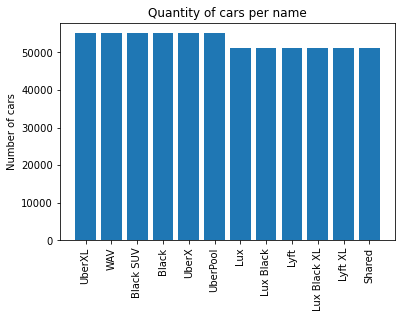

```python
#I made this as a general idea for a bar plot
from matplotlib import pyplot as plt
plt.bar(data['name'].value_counts().keys(),data['name'].value_counts().values)
plt.xticks(rotation=90)
plt.title("Quantity of cars per name")
plt.ylabel("Number of cars")
print("Most Frequent car: " + data['name'].mode().values[0])
plt.show()
```

## 3. Asking the Hard Questions

By now we should know all of the ins and outs about this dataset (right?). Let's dive a little deeper into it and see if we can find anything interesting.

### Problem 4

As you worked through the initial data processing and understanding phase, did anything catch your interest? Let's formulate some questions and hypotheses that you could explore in depth.

**Write-up!** Formulate and describe a question you have/want to investigate. Then, formulate and describe a hypothesis that can (possibly) answer it. What inspired your idea (provide specifics from the last section, if any)? How can you use the data to support or reject your hypothesis?

> **Hint**: Your question/hypothesis might be something that you are personally interested in or something that you think might lead to a product or service for users/customers. You might want to think about something that could help others in making decisions, etc.

*Grading Note: Your work will be graded for *creativity*. Be creative in the questions you ask/hypothesis you pose.*

**Answer here:** (feel free to make multiple cells!)

What would be the most popular car on each day of the week?

What is the most popular day of the week in the month of november?

What is the most popular time of day with each car? (Use this data to send more notifications to different types of cars)

**At peak hours, which is cheaper, Lyft or Uber? We hypothesize that Lyft is going to be cheaper at peak hours.**

### Problem 5

**Do this!** Let's explore your hypothesis. Find evidence from the data that supports or refutes your hypothesis and present it — recall that as a data scientist, one of your goals is to discover and communicate your results to your audience, *me*. The more thorough your analysis, the better!

> **Hint**: Even though we focus on EDA here, you may include some predictive modeling here as well.

Here's yet another *free* cell; use as many as you need.

Let's first split our data into uber and lyft! In this cell, we accessed the cab type and split the uber and lyft rides into two separate variables.

```python
uber = data[data['cab_type'] == 'Uber']
lyft = data[data['cab_type'] == 'Lyft']
```

Now, we are going to create a histogram that compares their most popular times. We first accessed the times for uber and lyft by pulling the "hour" data from each. After that, we plotted them together on one histogram and printed out our peak times

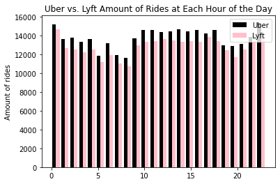

```
Peak times for Uber (in order): 12AM, 11PM, 10AM (0 = 12AM, 23 = 11PM)
Peak times for Lyft(in order): 12AM, 11PM, 5PM (0 = 12AM, 23 = 11PM)
```

```python
plt.hist
uber_time = uber['hour']
lyft_time = lyft['hour']
plt.hist([uber_time,lyft_time], bins = 24, color = ['black', 'pink'], label = ['Uber', 'Lyft'])
plt.title('Uber vs. Lyft Amount of Rides at Each Hour of the Day')
plt.ylabel('Amount of rides')
plt.legend()
plt.show()
print("Peak times for Uber (in order): 12AM, 11PM, 10AM (0 = 12AM, 23 = 11PM)")
print("Peak times for Lyft(in order): 12AM, 11PM, 5PM (0 = 12AM, 23 = 11PM)")
```

Now that we have our top 3 peak times for each company, let's put those peak times into variables. This can be done by accessing the uber and lyft time variables and masking them to when they are equal to the peak times we found.

```python
uber_peak = uber[(uber['hour'] == 0) | (uber['hour'] == 23) | (uber['hour'] == 10)]
lyft_peak = lyft[(lyft['hour'] == 0) | (lyft['hour'] == 23) | (lyft['hour'] == 17)]
```

Let's get the average prices from their peak times. This can be done by using the mean() and round() functions. The mean function will give us the average and the round function will help us round to the hundredths place, which gives us a more accurate number in dollar values

```python
# (the round function brings the numbers to the nearest hundredth, which accurately depicts a dollar amount.)
uber_peakAvg = round(uber_peak['price'].mean(), 2)
lyft_peakAvg = round(lyft_peak['price'].mean(), 2)
```

Time to visualize! Let's make a bar plot that compares the two average prices!

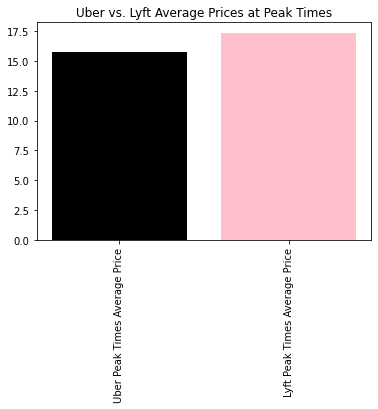

```
Uber Peak Times Average Price: $15.75
Lyft Peak Times Average Price: $17.38
```

```python
plt.bar(['Uber Peak Times Average Price', 'Lyft Peak Times Average Price'], [uber_peakAvg, lyft_peakAvg], color = ['black', 'pink'])
plt.title('Uber vs. Lyft Average Prices at Peak Times')
plt.xticks(rotation = 90)
plt.show()
# Showing the exact numbers so that the viewer can see the difference
print(f'Uber Peak Times Average Price: ${uber_peakAvg}')
print(f'Lyft Peak Times Average Price: ${lyft_peakAvg}')
```

Interesting, Uber seems to be cheaper on average at peak times... Let's simplify this even more to see if anything changes! Here, we get the peak numbers each into their own frame. We did this by repeating our step from up above but instead split up by each peak hour.

```python
# Uber peak hours
uber_peak0 = uber_peak[uber_peak['hour'] == 0]
uber_peak23 = uber_peak[uber_peak['hour'] == 23]
uber_peak10 = uber_peak[uber_peak['hour'] == 10]

# Lyft peak hours
lyft_peak0 = lyft_peak[lyft_peak['hour'] == 0]
lyft_peak23 = lyft_peak[lyft_peak['hour'] == 23]
lyft_peak17 = lyft_peak[lyft_peak['hour'] == 17]
```

Now let's start to get some averages of each of these so we can plot them against each other!

```python
# Average prices for Uber's peak hours
uber_peak0Avg = round(uber_peak0['price'].mean(), 2)
uber_peak23Avg = round(uber_peak23['price'].mean(), 2)
uber_peak10Avg = round(uber_peak10['price'].mean(), 2)

# Average prices for Lyft's peak hours
lyft_peak0Avg = round(lyft_peak0['price'].mean(), 2)
lyft_peak23Avg = round(lyft_peak23['price'].mean(), 2)
lyft_peak17Avg = round(lyft_peak17['price'].mean(), 2)
```

Now we're going to make bar plots to get a visualization for which is more expensive at each of their peak times in order

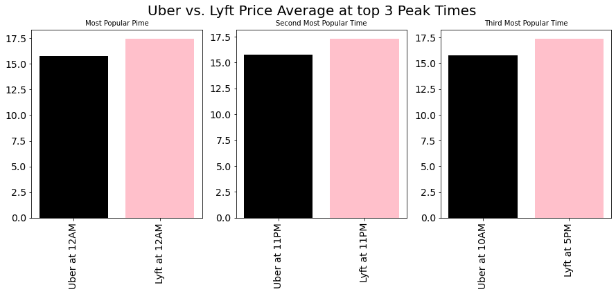

```
Uber 12AM Average Price: $15.73
Lyft 12AM Average Price: $17.45
Uber 11PM Average Price: $15.77
Lyft 11PM Average Price: $17.3
Uber 10AM Average Price: $15.76
Lyft 5PM Average Price: $17.38
```

```python
import matplotlib.pyplot as plt
from utility.util import configure_plots
#configuring the plots so we can have 3 plots in one spot
configure_plots()
plt.figure(figsize=(15, 5))
plt.suptitle("Uber vs. Lyft Price Average at top 3 Peak Times", fontsize=20)

# Plot for the most popular time
plt.subplot('131')
plt.bar(['Uber at 12AM', 'Lyft at 12AM'], [uber_peak0Avg, lyft_peak0Avg], color = ['black', 'pink'])
plt.title('Most Popular Pime', fontsize = 10)
plt.xticks(rotation = 90)

# Plot for the second most popular time
plt.subplot('132')
plt.bar(['Uber at 11PM', 'Lyft at 11PM'], [uber_peak23Avg, lyft_peak23Avg], color = ['black', 'pink'])
plt.title('Second Most Popular Time', fontsize = 10)
plt.xticks(rotation = 90)

# Plot for the third most popular time
plt.subplot('133')
plt.bar(['Uber at 10AM', 'Lyft at 5PM'], [uber_peak10Avg, lyft_peak17Avg], color = ['black', 'pink'])
plt.title('Third Most Popular Time', fontsize = 10)
plt.xticks(rotation = 90)
plt.show()

# Printing out the average prices so that it can be seen there are differences
print(f'Uber 12AM Average Price: ${uber_peak0Avg}')
print(f'Lyft 12AM Average Price: ${lyft_peak0Avg}')
print(f'Uber 11PM Average Price: ${uber_peak23Avg}')
print(f'Lyft 11PM Average Price: ${lyft_peak23Avg}')
print(f'Uber 10AM Average Price: ${uber_peak10Avg}')
print(f'Lyft 5PM Average Price: ${lyft_peak17Avg}')
```

WOW! Lyft ended up being more expensive on average during each of their top 3 peak times as well.

### Problem 6

**Write up!** Did you find anything interesting in Problem 5? If you did, tell me about it. If you don't think you found anything interesting, keep looking.

> **Hint**: Provide links to key figures in your discussion. See [this StackOverflow question](https://stackoverflow.com/questions/28080066/how-to-reference-a-ipython-notebook-cell-in-markdown) for details.

**Answer here:**

One of the most interesting findings was that Uber's third highest peak time was 10AM, and Lyft's was 5PM as seen here. This could be because it could be cheaper to take an Uber on the way to a normal workday but cheaper for Lyft on the way back from work.

Another really interesting finding was in the last bar graph. We believed that Uber would be more expensive for at least one of the top 3 peak times, but Lyft was expensive for every single time.

This could be because there might be more uber drivers than there are lyft drivers in Boston. Because of that, there is a similar demand without much supply, therefore lyft ends up being more expensive.

### Problem 7

One last step that we shouldn't skip is reviewing both our data analysis approach and also the data acquisition method.

**Write up!** Are there any shortcommings and/or **ethical issues** related to the way you used this data or formed your conclusions?

- Who are the stakeholders?
- How could someone other than yourself be impacted by any ethical issues arising from your analysis/work/product?
- Can you propose a way to resolve the issue(s)?

**Answer here:** (feel free to make multiple cells!)

Upon reflection, it's possible that different sized cars can lead to more expensive prices, and we didn't take that into account when we processed our data.

The stakeholders for this data analysis are Uber and Lyft employees that create the algorithms for the price calculations, because it's possible that lyft may need to reassess how they calculate price, at least in Boston.

Like I said, our analysis can affect the workers at Lyft or Uber, but also people who utilize these services. This data is only from November to December in Boston in 2018 so it can differ from month to month or even year.

One way to resolve the issue is to use more recent data and/or to focus in on the prices while also analyzing the particular cars used before diving into the average prices. Doing this would eliminate different car prices being a swaying factor

Let's conclude with thinking about imporvements for the future!

**Write up!** There are often times where the data you need doesn't exist (yet) and you need to go collect it. Based on your analysis of the data set, which features were informative and which weren't? What information that was missing from this dataset do you think would be helpful to have for next time?

**Answer here:** (feel free to make multiple cells!)

Honestly, I can't think of any data that I wanted that wasn't in this dataset. However, this dataset had way too many useless features to parse through. Such as sunriseTime, sunsetTime, moonPhase. I feel like that's the main problem I have with this dataset, however I'd prefer to have too many datapoints than not enough!

And that's it! Remember to review your work and make sure it is well presented and organized. Not everyting you coded up needs to remain in your submission. **[Does [this cell] spark joy?](https://i.kinja-img.com/gawker-media/image/upload/s--iW_3HGbT--/c_scale,dpr_2.0,f_auto,fl_progressive,q_80,w_800/oruf4oavtj5vpmvaquew.jpg)** You are always trying to communicate your findings to somebody, *maybe even yourself*.

> **Final Grading Note/Reminder**: Your work will be graded for *creativity*, *aesthetics*, *readability*, *style*, and *cleanlines*. So, carefully document your code and use descriptive/intuitive variable names. For write-ups use consice and clear language like in a written project report. Be creative in the questions you ask/hypothesis you pose as well as in the plots you use and select visulatizations and colors that make for a plesant and intuitive viewing expereince. The goal of a good visualization is that the viewer will quickly understand your figures.

```python
grader.check("hw6")
```

```
hw6
```

passed!

To double-check your work, the cell below will rerun all of the autograder tests.

```python
grader.check_all()
```

```
hw6 results: All test cases passed!
```

## Submission

Make sure you have run all cells in your notebook in order before running the cell below, so that all images/graphs appear in the output. The cell below will generate a zip file for you to submit. **Please save before exporting!**

```python
# Save your notebook first, then run this cell to export your submission.
grader.export(pdf=False)
```

Your submission has been exported. Click here to download the zip file.